# EEB177- Getting Started with Git and Github

Gaurav Kandlikar

December 31, 2016

**Note**: all instructions in this document are derived from [this guide](https://help.github.com/articles/set-up-git/). Your virtualbox already has the latest version of Git installed, so you can skip step 1 of the “Setting up Git” section.

### Setting up git locally

First, **we need to set up Git on the local machine**. Before we use Git for the first time, we need to tell it our name and email address. This allows your commits to have an author and a contact- note the author line on my git log. Here’s an example of a commit log from the [SESYNC Bayesian Analysis repository](https://github.com/gauravsk/SESYNCBayes)- notice that some commits were made by Mary Collins, others by CCheCastaldo:

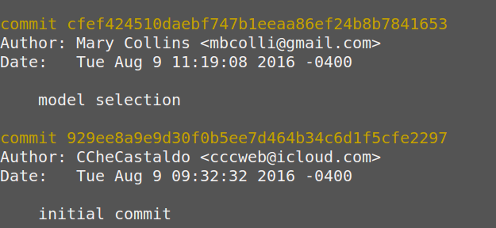

We set up our name and email address with the following commands in the terminal:

> `git config --global user.name "YOUR NAME"`

> `git config --global user.email "YOUR EMAIL ADDRESS"`

You can now use Git to do version control locally through your command line- hurray! To start using Git, use your terminal to navigate to the `course_assignments` folder on the Desktop:

> `cd ~/Desktop/course_assignments`

Confirm that you made it into the `course_assignments` folder by entering the command `pwd`. This command returns the path to the current working directory. We want this folder to be tracked using git: for each weeks assignment, you are to make a new subfolder within this folder and use Git+Github to have the weekly subfolders pushed through to github.

To start tracking this folder using git, enter the following command:

> `git init`

*Note*: this command only needs to be run when first setting up a new git repository.

It is good practice to initialize each git folder with a README file that explains the purpose of the repository. Your `course_assignments` folder already has a file `README.txt`. We can ask git to start tracking that file with the following command:

> `git add README.txt`

*Note*: this command needs to be run every time there is a version of a file (or subfolder) that we’d like to take a snapshot of with Git (e.g. `git add zebra_pictures` to take a snapshot of a folder called `zebra_pictures`).

We can “commit” this file as a version that we want to save a snapshot off using the following command:

> `git commit -m "initial commit: adding a barebones README file"`

*Note*: `-m` is a *flag* that says that this particular commit should be made with the message “initial commit: adding a barebones README file”.

You can look over the (brief) history of your git repository by asking to see its log:

> `git log`

### Updating the readme and committing the changes

Before moving on, we need to update the barebones `README.txt` to include some more information (e.g. your name, email address, lab section).

**Task**: Open up `README.txt` (through the terminal, using `gedit README.txt`, or by navigating to it in your desktop and double-clicking), and add the requested information. Then, take a snapshot of the file using `git add` and commit the changes with a message using `git commit` as above. Verify using `git log`.

### Getting Github to talk to your computer

You now have a functioning Git repository on your computer- hurray! Now, we need to connect it to your Github account so that the files and commit history on your computer can be “pushed” through to be available online.

Log into your account on github, and click “New repository” on the right hand column. Give it an appropriate name (it will contain assignments for this course), and keep it public. On the “Quick setup” page, make sure that “HTTPS” is selected- *not* “SSH”. Copy the code under “…or push an existing repository from the command line”, return to the terminal, and paste in the two lines. You will be prompted for a username and password; these are your github credentials.

*Note*: As it stands, you will need to enter your username and password every time you wish to use `git push`. Run the following two commands in your terminal to store your credentials for one hour (i.e. you will have to enter your username/pwd once every hour):

> `# Set git to use the credential memory cache:`  
> `git config --global credential.helper cache`

> `# Set the cache to timeout after 1 hour (setting is in seconds):`  
> `git config --global credential.helper 'cache --timeout=3600'`

If you now navigate to your new repository on github, you should see your assignments folder with a solid README. Congrats!